# Early-Onset Breast Cancer in METABRIC: Clinical and Genomic Features of Patients Diagnosed Under 40 and Their Prognostic Significance Across PAM50 Subtypes

Yuliya Savenko

26 February 2026

# Abstract

**Background:** Breast cancer diagnosed in women under 40 is known to carry worse outcomes than later-onset disease, but it is not entirely clear how much of this is explained by younger women having more aggressive subtypes versus age having an independent effect within molecular subgroups. This report uses the METABRIC cohort to try and address this question.

**Conclusions:** Subtype distribution alone does not fully explain the survival disadvantage of early-onset breast cancer in this cohort. Age-specific genomic features and a genuine within-subtype age effect are both detectable, and these findings have implications for how young patients with luminal disease are managed clinically.

# Introduction

Breast cancer diagnosed before age 40, commonly termed adolescent and young adult (AYA) breast cancer, is associated with disproportionately poor outcomes. In developed countries, it is the leading cause of cancer-related death in women in this age group, and younger patients experience inferior survival even after adjustment for stage and grade (Cathcart-Rake et al., 2021). This disparity is partly attributed to tumour biology. Younger women are more likely to present with aggressive intrinsic subtypes such as Basal-like and Luminal B, to harbour germline *BRCA1/2* or *TP53* mutations, and to face endocrine and fertility-related treatment complexities (Anastasiadi et al., 2017).

However, emerging evidence suggests that age-related biological differences extend beyond subtype distribution. Within Luminal A—the most prognostically favourable PAM50 category—tumours arising in younger women exhibit increased proliferative signalling and endocrine resistance signatures compared with those in older patients (Azim et al., 2015). These observations raise the possibility that age exerts an independent biological effect within intrinsic subtypes.

We therefore hypothesise that early-onset breast cancer represents a biologically distinct entity within PAM50 strata. If this is the case, younger patients should demonstrate subtype-specific differences in somatic mutation profiles and survival outcomes that persist after accounting for subtype classification and standard clinical covariates. Transcriptional differences observed in younger patients should be reflected in measurable genomic divergence—such as altered driver gene frequencies or tumour mutation burden—and in differential survival within subtype-defined groups.

To test this hypothesis, we analysed data from the METABRIC cohort, a large, publicly available breast cancer dataset comprising nearly 2,000 patients with linked clinical, genomic, and transcriptomic information (Curtis et al., 2012; Pereira et al., 2016). Using clinical data including PAM50 subtype, receptor status, menopausal status, treatment records, and overall survival, together with somatic mutation data in MAF format, we examined whether early-onset (<40 years) patients differ from older patients across four dimensions. These were subtype distribution; driver mutation frequency and tumour mutation burden within subtype; survival after adjustment for subtype and other covariates; and treatment-associated survival patterns in premenopausal ER-positive disease.

By explicitly testing whether age retains biological and prognostic significance within intrinsic subtypes, this study aims to determine whether early-onset breast cancer reflects merely a shift in subtype prevalence or a distinct biological phenotype with independent clinical implications.

# Methods

Two METABRIC files were analysed. The first was a clinical table containing demographics, menopausal status, ER status by immunohistochemistry, HER2 copy-number status by SNP array, treatment indicators (chemotherapy, hormone therapy, radiotherapy), PAM50 subtype labels, and overall survival time and status. The second was a somatic mutation MAF file containing 17,272 variant calls across 2,369 patients.

METABRIC is a de-identified secondary-use research resource. This report uses publicly available patient-level data with no direct identifiers; all analyses are at cohort level with no attempt at re-identification, consistent with the original study’s governance framework.

Variables were renamed and a known typographic error in ER status corrected. Survival status was recoded to a binary event indicator. Age was retained as a continuous covariate and discretised into five bands (<40, 40–49, 50–59, 60–69, ≥70) for descriptive stratification. Patients with unclassified (NC) PAM50 designations were excluded; missing values were handled by complete-case analysis. No imputation was applied.

Mutations were loaded using `maftools::read.maf()` with clinical annotations keyed on tumour sample barcode. Only non-synonymous variants are retained by default. Samples without PAM50 labels were excluded from subtype-stratified analyses.

Cohort-level mutation composition was summarised using `plotmafSummary()` and gene-level recurrence using oncoplots. Tumour mutation burden (non-synonymous mutations per sample) was compared across PAM50 groups and age groups using Kruskal–Wallis tests; extreme outliers were trimmed for visualisation only. Pairwise subtype and age-group comparisons used `coOncoplot()`. Gene–gene co-occurrence and mutual exclusivity among the top 20 mutated genes were assessed using `somaticInteractions()` with Fisher’s exact tests.

Overall survival was defined as time from diagnosis to death or censoring. Kaplan–Meier estimates were compared across PAM50 subtypes using log-rank tests. A multivariable Cox model was fitted with age (continuous), menopausal status, ER status, HER2 copy-number gain, chemotherapy, and PAM50 subtype (LumA reference), reporting hazard ratios with 95% confidence intervals.

Premenopausal ER-positive patients were stratified by PAM50 (LumA vs LumB) and age group (<40 vs ≥40). Treatment receipt rates were compared descriptively. A Cox model adjusting for continuous age, subtype, and treatment group was used to assess whether early onset modifies treatment response. Given the observational design and confounding by indication, all estimates should be treated as associative rather than causal.

# Results

## 0. Data Exploration and Cohort Description

Table 1. Cohort characteristics by age group (<40 vs ≥40 years at diagnosis).

| Characteristic | <40 | ≥40 |
| --- | --- | --- |
| N | 120 | 1854 |
| Age, median (IQR) | 36.5 (33.7–38.2) | 63.0 (53.7–71.0) |
| ER Positive (%) | 35.6 | 80.0 |
| HER2 Gain (%) | 31.7 | 21.5 |
| Premenopausal (%) | 100.0 | 16.4 |
| LumA (%) | 16.7 | 36.7 |
| LumB (%) | 9.2 | 25.0 |
| Basal (%) | 29.2 | 9.4 |
| Her2 (%) | 17.5 | 10.9 |
| Deceased (%) | 47.5 | 58.3 |
| Median OS (months) | 83.7 | 117.6 |

Completeness checks confirmed no missing values for age, PAM50, or survival status. ER status had <1% missing, handled by complete-case analysis. No duplicate patient IDs were detected.

## 1. Biological Differences Between the Two AYA-Enriched PAM50 Subtypes

### 1.2 Subtype Distribution and AYA Enrichment

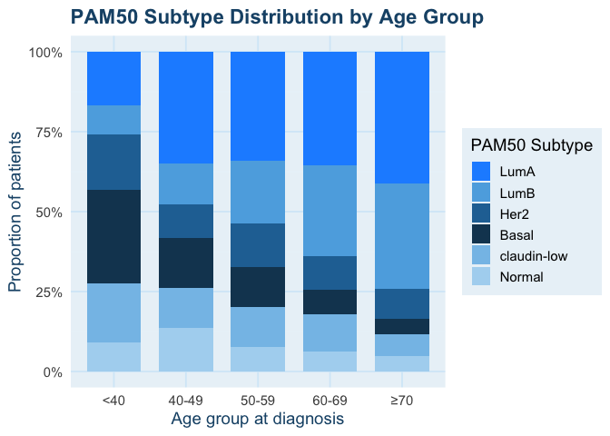

### 1.3 Clinical Biomarker Profiles: ER, HER2, and Proliferative Markers

Since PAM50 subtypes are defined by their expression programmes, clinical biomarkers provide measurable proxies for the underlying biology. ER and HER2 status, menopausal state, and treatment allocation (Figure 2) are compared between LumB and Basal-like across age groups; the proportions in each bar directly reflect the biological separation between the two subtypes.

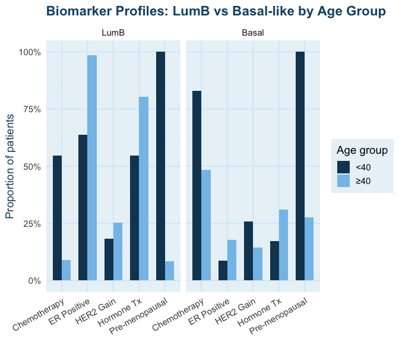

**Figure 2.** Clinical biomarker and treatment profiles for Luminal B and Basal-like subtypes, stratified by age group (<40 vs ≥40). Proportions shown within each subtype–age combination. The contrast between ER-positive LumB and triple-negative Basal-like is the dominant biological signal; age modifies this within each subtype.

### 1.4 Age at Diagnosis and Subtype Overlap

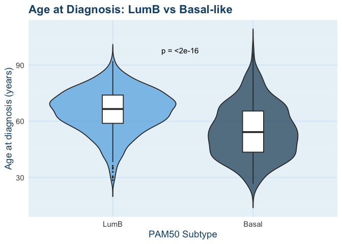

### 1.5 Summary: Dominant Biological Signals Between LumB and Basal-like

The dominant biological signal is the ER/triple-negative divide. LumB retains luminal differentiation and ER-driven growth, while Basal-like is defined by proliferative and DNA-damage-response biology. Within both subtypes, younger patients are more likely to be pre-menopausal, modifying treatment options independently of tumour biology. Basal-like shows stronger age enrichment, consistent with its association with BRCA1 germline variants and *TP53* mutations prevalent in younger patients.

## 2. Age-Stratified Mutational Landscape

### 2.1 Loading Mutation Data

This section examines somatic mutation data to ask whether early-onset patients have a different profile from older patients, and whether any differences are subtype-specific or more general.

### 2.2 Mutational Landscape Overview

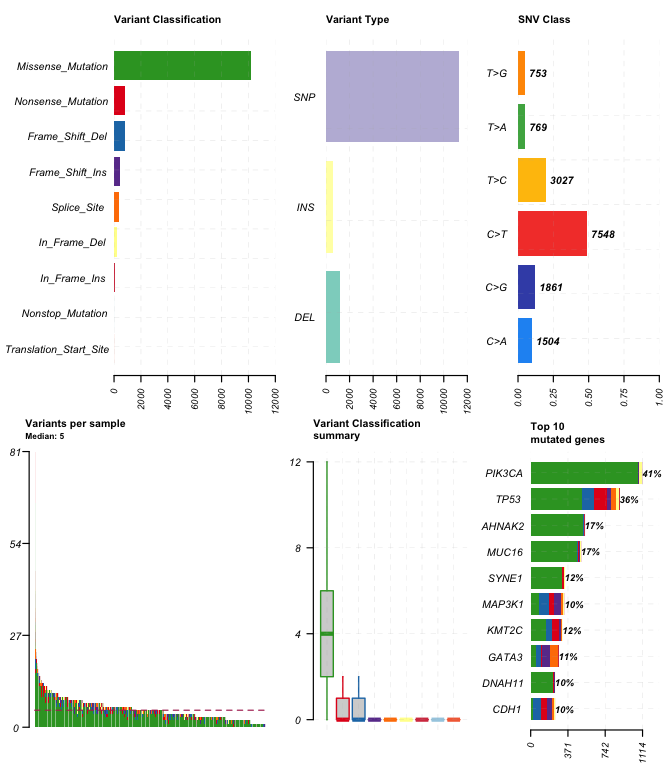

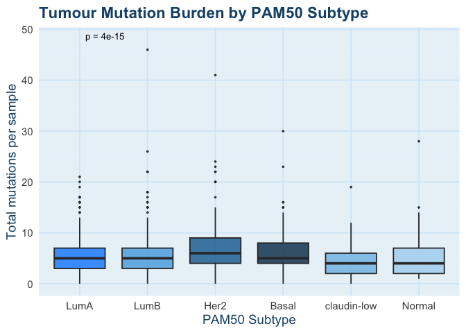

### 2.3 Key Cancer Driver Genes and Age-Associated Enrichment Patterns

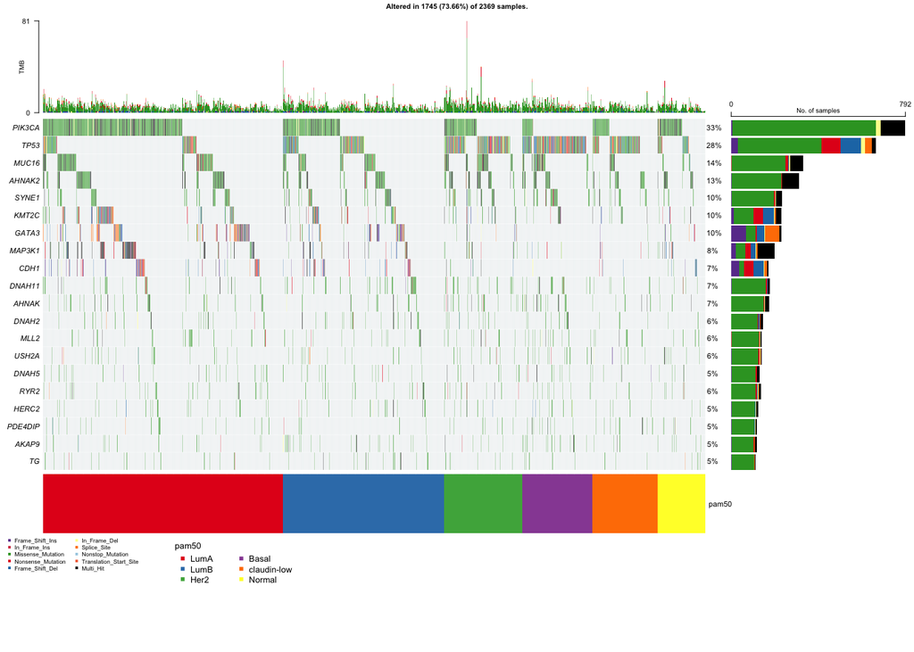

**Figure 6.** Oncoplot showing the top 20 most frequently mutated genes across the METABRIC cohort, annotated by PAM50 subtype. PIK3CA and GATA3 mutations, enriched in luminal disease, show age-related differences described in Section 2.4.

Table 2. Top 15 most frequently mutated genes in the METABRIC cohort.

| Gene | Mutated samples | Frequency (%) |
| --- | --- | --- |
| PIK3CA | 975 | 41.2 |
| TP53 | 861 | 36.3 |
| MUC16 | 409 | 17.3 |
| AHNAK2 | 395 | 16.7 |
| SYNE1 | 293 | 12.4 |
| KMT2C | 277 | 11.7 |
| GATA3 | 267 | 11.3 |
| MAP3K1 | 236 | 10.0 |
| CDH1 | 233 | 9.8 |
| DNAH11 | 226 | 9.5 |
| AHNAK | 219 | 9.2 |
| DNAH2 | 183 | 7.7 |
| MLL2 | 176 | 7.4 |
| USH2A | 170 | 7.2 |
| DNAH5 | 165 | 7.0 |

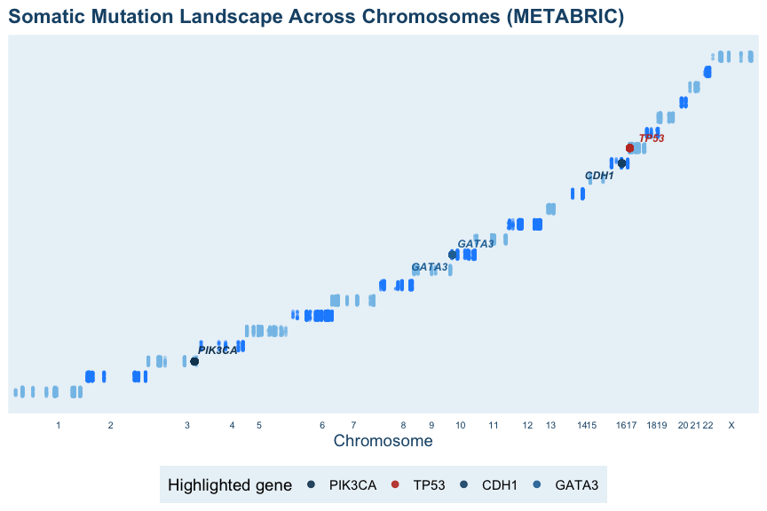

**Figure 7.** Manhattan plot of somatic mutations across chromosomes in the METABRIC cohort. Each point represents a mutation; chromosomes are alternately shaded. Top driver genes (*PIK3CA*, *TP53*, *CDH1*, *GATA3*) are highlighted and labelled. GATA3 (10q14) and PIK3CA (3q26) show luminal enrichment patterns with known age-related differences.

The Manhattan plot shows driver mutations clustering at the expected loci — *PIK3CA* at 3q26, *TP53* at 17p13, and *GATA3* at 10q14. Of these, *GATA3* is probably the most relevant to the AYA analysis given its reported enrichment in younger luminal patients and a possible role in endocrine resistance (Azim et al., 2015).

### 2.4 Subtype-Specific and Age-Stratified Mutation Patterns

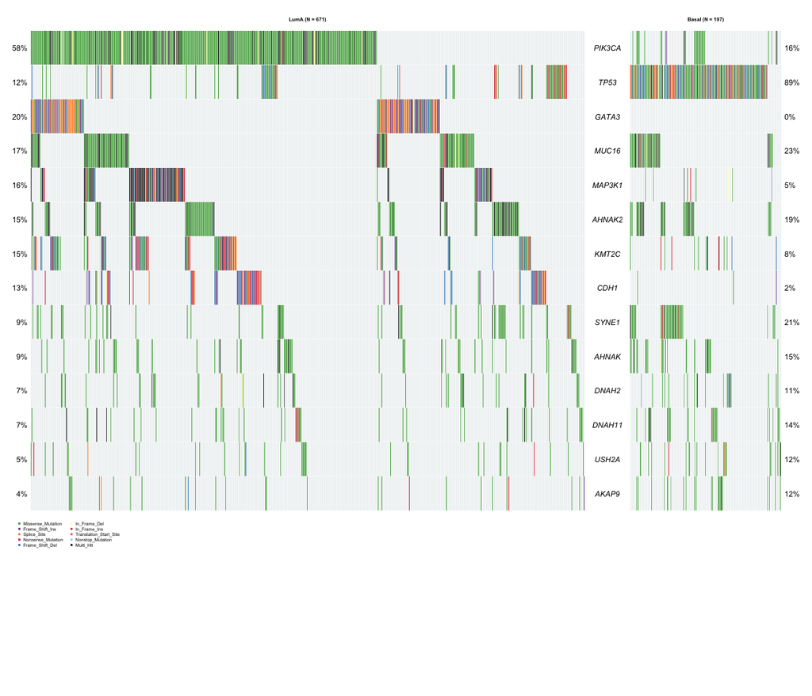

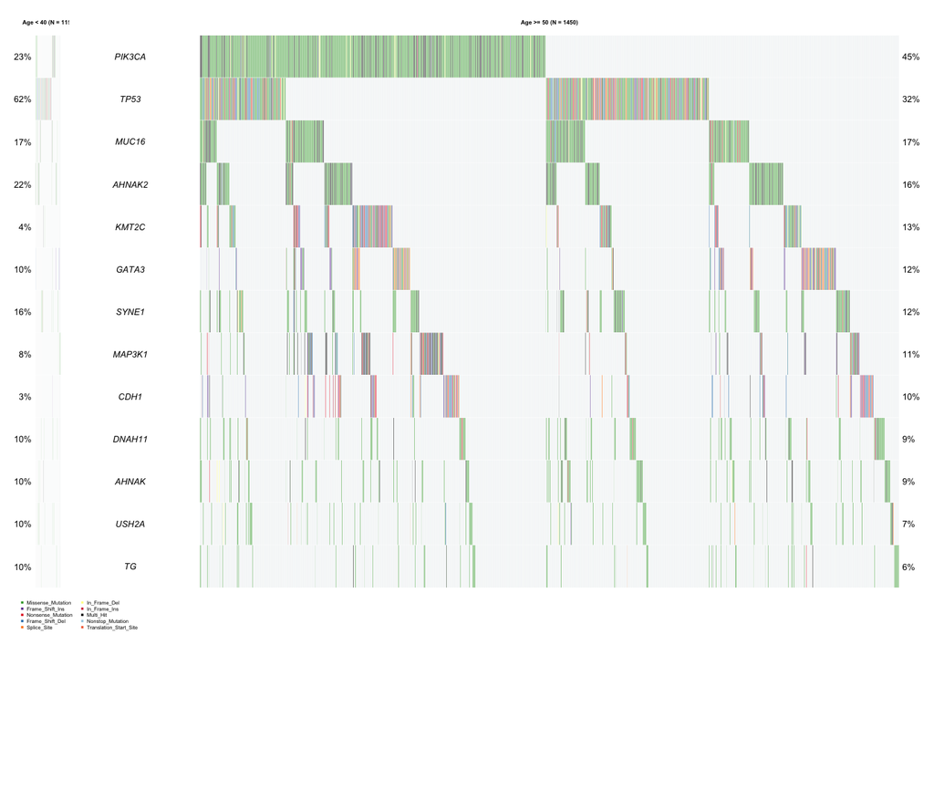

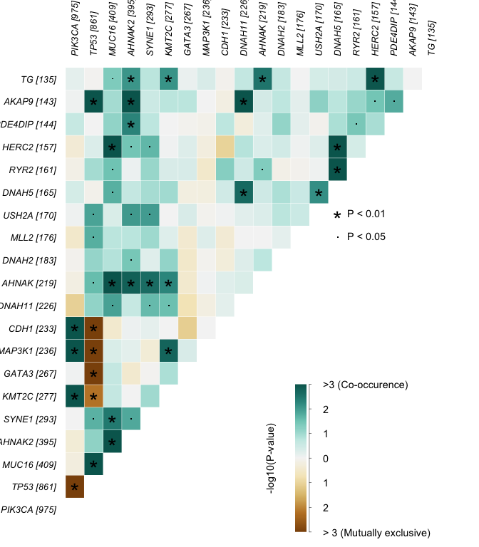

**Figure 10.** Somatic interaction plot showing co-occurrence and mutual exclusivity among the top 20 mutated genes. The PIK3CA–TP53 mutual exclusivity encodes the fundamental divide between luminal (predominantly older, PIK3CA-driven) and basal (predominantly younger, TP53-driven) oncogenic programmes.

## 3. Age at Diagnosis as an Independent Predictor of Survival Across PAM50 Subtypes

### 3.1 Age Group and Subtype Interaction on Survival

Section 3 addresses whether age at diagnosis independently predicts overall survival, and whether any effect is uniform across subtypes or concentrated in some more than others.

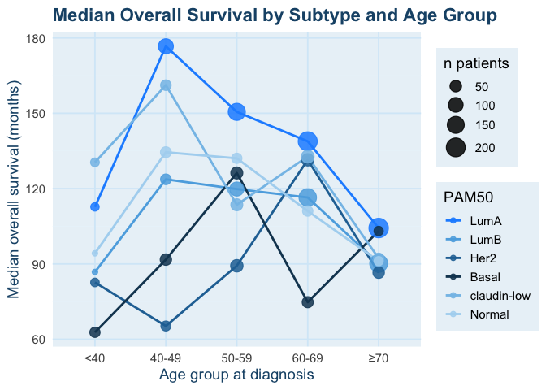

**Figure 11.** Median overall survival by PAM50 subtype and age group. This is the primary descriptive figure for the report’s central question: does age modify the prognostic impact of subtype? The <40 group shows a distinct trajectory in LumA and LumB that is explored further in the Cox model.

### 3.2 Overall Survival by PAM50 Subtype

The Kaplan–Meier curves (Figure 12) establish the overall subtype survival picture before examining age-related modifications.

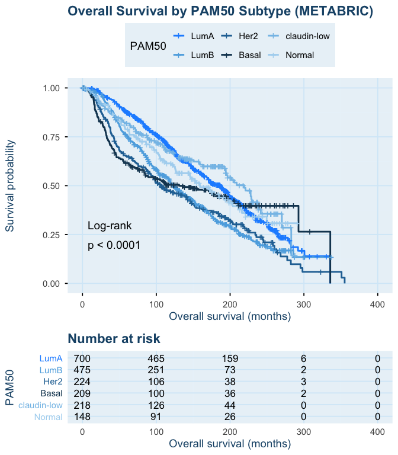

**Figure 12.** Kaplan–Meier overall survival curves stratified by PAM50 subtype. P-value from log-rank test. These overall curves provide context for Figure 11, which shows how median survival within each subtype varies by age group.

LumA has clearly the best survival and Basal-like and HER2-enriched show the steepest early decline, consistent with the literature. The overall subtype differences are highly significant (log-rank p < 0.001). Readers should note the crossing of the Basal-like and HER2-enriched curves at approximately 60–80 months, which has implications for the proportional hazards assumption discussed in the Limitations.

### 3.3 Multivariate Cox Model: Age as Independent Predictor Within Subtypes

To properly test whether age has an independent effect on survival beyond its association with subtype, a multivariable Cox model was fitted including PAM50 subtype, ER status, HER2 gain, menopausal status, and chemotherapy.

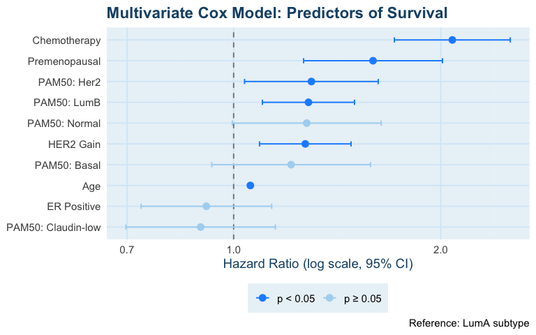

**Figure 13.** Forest plot of multivariate Cox proportional hazards model. Reference subtype: LumA. Age is entered as a continuous covariate; its hazard ratio represents the per-year increase in mortality risk independent of subtype and other clinical variables.

Table 3. Multivariate Cox model results.

| term | HR | std.error | statistic | p-value | 95% CI low | 95% CI high |
| --- | --- | --- | --- | --- | --- | --- |
| age | 1.06 | 0.0038251 | 14.6088055 | 2.47e-48 | 1.05 | 1.07 |
| pre_meno | 1.59 | 0.1185193 | 3.9354674 | 8.30e-05 | 1.26 | 2.01 |
| er_bin | 0.91 | 0.1115133 | -0.8185046 | 4.13e-01 | 0.73 | 1.14 |
| her2_gain | 1.27 | 0.0781271 | 3.0681362 | 2.15e-03 | 1.09 | 1.48 |
| chemo_bin | 2.08 | 0.0989548 | 7.3948663 | 1.42e-13 | 1.71 | 2.52 |
| pam50LumB | 1.28 | 0.0786206 | 3.1840960 | 1.45e-03 | 1.10 | 1.50 |
| pam50Her2 | 1.30 | 0.1141185 | 2.2802517 | 2.26e-02 | 1.04 | 1.62 |
| pam50Basal | 1.21 | 0.1355015 | 1.4197250 | 1.56e-01 | 0.93 | 1.58 |
| pam50claudin-low | 0.90 | 0.1275435 | -0.8649083 | 3.87e-01 | 0.70 | 1.15 |
| pam50Normal | 1.28 | 0.1270239 | 1.9256134 | 5.42e-02 | 1.00 | 1.64 |

### 3.4 Treatment Patterns by Subtype and Menopausal Status

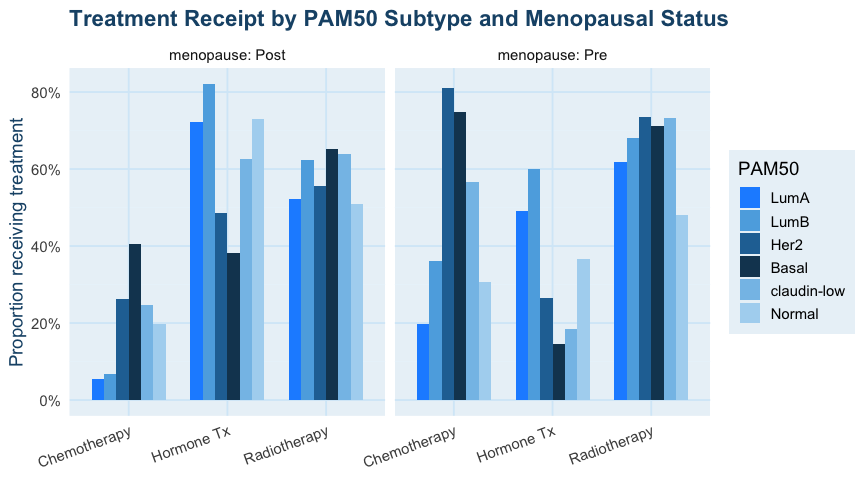

**Figure 14.** Treatment receipt rates by PAM50 subtype and menopausal state.

### 3.5 Survival Implications of Age-Subtype Interaction

The survival penalty of young age is most pronounced in luminal subtypes, where the expected favourable prognosis of LumA or LumB appears partially undermined at young age (Azim et al., 2015). For Basal-like, the subtype biology is so dominant that age is harder to disentangle as an independent factor.

## 4. Does early onset modify treatment outcomes in premenopausal ER-positive breast cancer?

### 4.1 Rationale and Study Group

Table 4. Patient counts by PAM50 subtype, AYA status, and treatment group (premenopausal, ER-positive only).

| pam50 | aya_group | Hormone only | Both | Neither | Chemo only |
| --- | --- | --- | --- | --- | --- |
| LumA | AYA (<40) | 6 | 5 | 8 | 0 |
| LumA | Premenopausal ≥40 | 33 | 17 | 52 | 0 |
| LumB | AYA (<40) | 3 | 2 | 2 | 0 |
| LumB | Premenopausal ≥40 | 15 | 8 | 12 | 1 |

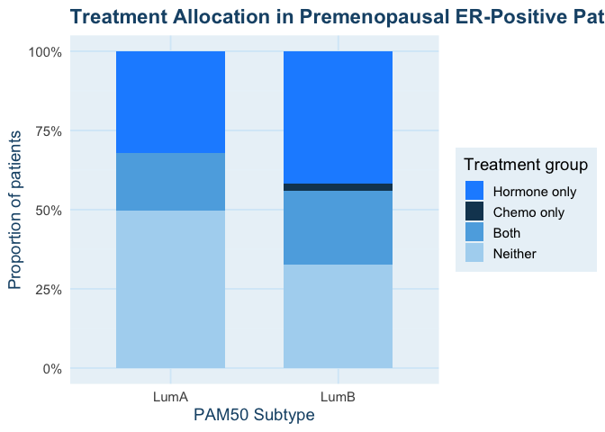

**Figure 15.** Treatment group distribution in premenopausal ER-positive patients, split by PAM50 subtype. LumB patients receive more chemotherapy-inclusive regimens, a pattern that is particularly pronounced in AYA patients whose higher-risk tumour profiles trigger more aggressive treatment allocation.

### 4.2 Kaplan–Meier Survival by Treatment Group

[figure not shown]

**Figure 16.** Kaplan–Meier overall survival curves in premenopausal ER-positive patients, stratified by treatment group and PAM50 subtype. P-values from log-rank tests. These curves show the subtype-level patterns; age-group stratification within this population is discussed in Section 4.5.

The KM curves (Figure 16) show hormone-only treatment tracking with good outcomes in LumA, while LumB shows more separation between treatment groups, suggesting hormone therapy alone may not be sufficient for a notable proportion of LumB patients. Table 6 gives the absolute event counts and median OS values supporting this interpretation — in LumB, median OS in the hormone-only group is visibly lower than in LumA, and mortality rates are higher across all treatment categories.

### 4.3 Multivariate Cox Model: Treatment Effect Adjusted for Age

Because treatment assignment is not random, as clinicians preferentially give chemotherapy to younger, higher-risk patients, a raw KM comparison may confound treatment benefit with baseline risk. A Cox model adjusting for age and subtype provides a more reliable estimate of the independent treatment effect.

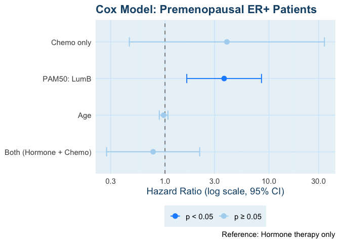

**Figure 17.** Forest plot of Cox model for premenopausal ER-positive patients. Reference: hormone therapy only. Age is included as a continuous covariate to estimate whether the survival penalty of early onset persists after adjusting for subtype and treatment group.

Table 5. Cox proportional hazards model results for premenopausal ER-positive patients.

| term | HR | std.error | statistic | p-value | 95% CI low | 95% CI high |
| --- | --- | --- | --- | --- | --- | --- |
| age | 0.97 | 0.0487210 | -0.6362395 | 5.25e-01 | 0.88 | 1.07 |
| pam50LumB | 3.71 | 0.4224563 | 3.1011802 | 1.93e-03 | 1.62 | 8.48 |
| tx_groupChemo only | 3.94 | 1.1023915 | 1.2436361 | 2.14e-01 | 0.45 | 34.18 |
| tx_groupBoth | 0.77 | 0.5262750 | -0.5011186 | 6.16e-01 | 0.27 | 2.15 |

### 4.4 Median Survival and Mortality Summary

Table 6. Survival summary by subtype and treatment group (premenopausal ER-positive patients).

| pam50 | tx_group | N | Deaths | Mortality (%) | Median OS (months) | Mean OS (months) |
| --- | --- | --- | --- | --- | --- | --- |
| LumA | Hormone only | 39 | 9 | 23.1 | 176.8 | 165.2 |
| LumA | Both | 22 | 2 | 9.1 | 125.8 | 122.9 |
| LumB | Hormone only | 18 | 10 | 55.6 | 122.3 | 127.0 |
| LumB | Chemo only | 1 | 1 | 100.0 | 64.7 | 64.7 |
| LumB | Both | 10 | 3 | 30.0 | 114.0 | 104.7 |

### 4.5 Interpretation: Does Early Onset Modify Subtype-Level Treatment Response?

LumA patients on hormone therapy alone generally do well, consistent with limited chemotherapy benefit in low-risk ER-positive patients (Prat et al., 2015). LumB tells a different story. Hormone therapy alone appears insufficient for a proportion of patients, consistent with elevated endocrine resistance in young LumB tumours. This supports more intensive endocrine therapy — specifically ovarian suppression plus aromatase inhibitor — in the youngest premenopausal LumB patients (Rosenberg & Partridge, 2015). Readers should refer to Table 5 for the age HR in this subgroup. Given the small <40 group within LumB, findings are directional and hypothesis-generating.

# Discussion

## Summary of Key Findings

The results of this analysis broadly support the hypothesis that early-onset breast cancer is not simply adult disease occurring at a younger age, but a biologically distinct entity with its own subtype distribution, genomic profile, and survival trajectory.

The most striking finding from Section 1 was the shift in subtype composition in younger patients. Basal-like and claudin-low tumours are markedly overrepresented in the <40 group. Since these are predominantly triple-negative, this alone explains much of the survival disadvantage — there are no hormone or HER2 targets to exploit.

## Limitations

The most fundamental limitation is the cohort’s historical span (recruitment approximately 1977–2005), during which treatment evolved substantially. Trastuzumab was unavailable for most of the recruitment period, so HER2-enriched survival outcomes underestimate what modern anti-HER2 therapy achieves; similarly, Basal-like outcomes predate PARP inhibitors and platinum-based chemotherapy in BRCA-mutant TNBC.

Clinical biomarkers (ER by IHC, HER2 by SNP array) are used as proxies for molecular biology, introducing noise. Ki67 is unavailable, which is problematic for distinguishing LumA from LumB; some subtype misclassification is likely.

The Cox models were fitted without formally testing the proportional hazards assumption. Given that LumB and Basal-like survival curves cross in the KM plots (Figure 12), reported hazard ratios should be understood as time-averaged estimates. Treatment analyses in Section 4 are subject to confounding by indication and are hypothesis-generating only. The <40 subgroup is small enough within individual subtypes that KM curves at later time points are unreliable.

## Suggestions for Future Development

The most immediate extension would be adding age–subtype interaction terms to the Cox model to formally test whether the within-subtype age effect differs across subtypes — the current main-effects model cannot answer this, and Figure 11 suggests the penalty may be larger in LumA than Basal-like.

Using the METABRIC gene expression microarray data to directly compare transcriptomic profiles of early-onset versus older patients within each subtype would move the analysis beyond biomarker proxies, enabling direct characterisation of proliferative index, endocrine resistance signatures, and pathway activity by age group.

Mutational signature decomposition would be informative, particularly for quantifying BRCA-associated HRD (Signature 3) in young Basal-like patients and APOBEC activity in young HER2-enriched patients. Pooling with TCGA data would address the small <40 sample sizes.

# Conclusion

The within-subtype age effect is small but detectable, and it appears most relevant in luminal disease. In the premenopausal ER-positive group, the patterns are consistent with elevated endocrine resistance at young age in LumB, though the sample is genuinely too small in METABRIC to make strong claims here.

Taken together, these results suggest that PAM50 subtype alone is not enough to fully characterise risk in young women. Age-specific biology matters and probably deserves more explicit consideration in how young patients, particularly those with luminal disease, are treated and monitored clinically.

# References

Mayakonda A, Lin DC, Assenov Y, Plass C, Koeffler HP. Maftools: efficient and comprehensive analysis of somatic variants in cancer. *Genome Research*. 2018;28(11):1747–1756. https://doi.org/10.1101/gr.239244.118

Gendoo DMA, Ratanasirigulchai N, Schröder MS, et al. Genefu: an R/Bioconductor package for computation of gene expression-based signatures in breast cancer. *Bioinformatics*. 2016;32(7):1097–1099. https://doi.org/10.1093/bioinformatics/btv693

Curtis C, Shah SP, Chin SF, et al. The genomic and transcriptomic architecture of 2,000 breast tumours reveals novel subgroups. *Nature*. 2012;486:346–352. https://doi.org/10.1038/nature10983

Anastasiadi Z, Lianos GD, Ignatiadou E, Harissis HV, Mitsis M. Breast cancer in young women: an overview. *Updates in Surgery*. 2017;69(3):313–317. https://doi.org/10.1007/s13304-017-0424-1

Azim HA Jr, Nguyen B, Brohée S, Zoppoli G, Sotiriou C. Genomic aberrations in young and elderly breast cancer patients. *BMC Medicine*. 2015;13:266. https://doi.org/10.1186/s12916-015-0504-3

Azim HA Jr, Partridge AH. Biology of breast cancer in young women. *Breast Cancer Research*. 2014;16:427. https://doi.org/10.1186/s13058-014-0427-5

Cathcart-Rake EJ, Ruddy KJ, Bleyer A, Johnson RH. Breast cancer in adolescent and young adult women under the age of 40 years. *JCO Oncology Practice*. 2021;17(6):305–313. https://doi.org/10.1200/OP.20.00793

Klauber-DeMore N. Tumor biology of breast cancer in young women. *Breast Disease*. 2005/2006;23:9–15. https://doi.org/10.3233/bd-2006-23103

Pereira B, Chin SF, Rueda OM, et al. The somatic mutation profiles of 2,433 breast cancers refines their genomic and transcriptomic landscapes. *Nature Communications*. 2016;7:11479. https://doi.org/10.1038/ncomms11479

Prat A, Pineda E, Adamo B, et al. Clinical implications of the intrinsic molecular subtypes of breast cancer. *The Breast*. 2015;24(Suppl 2):S26–S35. https://doi.org/10.1016/j.breast.2015.07.008

Rosenberg SM, Partridge AH. Management of breast cancer in very young women. *The Breast*. 2015;24(Suppl 2):S154–S158. https://doi.org/10.1016/j.breast.2015.07.036

Torres-Mejía G, Navarro-López E, de Jesús Tuesca-Molina R, Ángeles-Llerenas A. The epidemiological challenges of breast cancer among premenopausal women in limited resource settings. *Revista de Investigación Clínica*. 2017;69(2):59–65. DOI https://doi.org/10.24875/ric.17002239

**Data and Code Availability**

All files associated with this report, including the R Markdown source, data files, and supplementary materials, are available at: [https://github.com/Yuliya0257/Y.Savenko-Module-3-files](https://github.com/Yuliya0257/Y.Savenko-Module-3-files.git)